# Exploratory - Ford Go Bike's data - Feb 2019

Definitions:

Trip Duration (seconds)

Start Time and Date

End Time and Date

Start Station ID

Start Station Name

Start Station Latitude

Start Station Longitude

End Station ID

End Station Name

End Station Latitude

End Station Longitude

Bike ID

User Type (Subscriber or Customer)

|  | duration_sec | start_time | end_time | start_station_id | start_station_name | start_station_latitude | start_station_longitude | end_station_id | end_station_name | end_station_latitude | end_station_longitude | bike_id | user_type | member_birth_year | member_gender | bike_share_for_all_trip |
| --- | --- | --- | --- | --- | --- | --- | --- | --- | --- | --- | --- | --- | --- | --- | --- | --- |
| 0 | 52185 | 2019-02-28 17:32:10.1450 | 2019-03-01 08:01:55.9750 | 21 | Montgomery St BART Station (Market St at 2nd St) | 37.789625 | -122.400811 | 13 | Commercial St at Montgomery St | 37.794231 | -122.402923 | 4902 | Customer | 1984.0 | Male | No |
| 1 | 42521 | 2019-02-28 18:53:21.7890 | 2019-03-01 06:42:03.0560 | 23 | The Embarcadero at Steuart St | 37.791464 | -122.391034 | 81 | Berry St at 4th St | 37.775880 | -122.393170 | 2535 | Customer | NaN | NaN | No |
| 2 | 61854 | 2019-02-28 12:13:13.2180 | 2019-03-01 05:24:08.1460 | 86 | Market St at Dolores St | 37.769305 | -122.426826 | 3 | Powell St BART Station (Market St at 4th St) | 37.786375 | -122.404904 | 5905 | Customer | 1972.0 | Male | No |
| 3 | 36490 | 2019-02-28 17:54:26.0100 | 2019-03-01 04:02:36.8420 | 375 | Grove St at Masonic Ave | 37.774836 | -122.446546 | 70 | Central Ave at Fell St | 37.773311 | -122.444293 | 6638 | Subscriber | 1989.0 | Other | No |
| 4 | 1585 | 2019-02-28 23:54:18.5490 | 2019-03-01 00:20:44.0740 | 7 | Frank H Ogawa Plaza | 37.804562 | -122.271738 | 222 | 10th Ave at E 15th St | 37.792714 | -122.248780 | 4898 | Subscriber | 1974.0 | Male | Yes |

```
<class 'pandas.core.frame.DataFrame'>
RangeIndex: 183412 entries, 0 to 183411
Data columns (total 16 columns):
 #   Column                   Non-Null Count   Dtype
---  ------                   --------------   -----
 0   duration_sec             183412 non-null  int64
 1   start_time               183412 non-null  object
 2   end_time                 183412 non-null  object
 3   start_station_id         183215 non-null  object
 4   start_station_name       183215 non-null  object
 5   start_station_latitude   183412 non-null  float64
 6   start_station_longitude  183412 non-null  float64
 7   end_station_id           183215 non-null  object
 8   end_station_name         183215 non-null  object
 9   end_station_latitude     183412 non-null  float64
 10  end_station_longitude    183412 non-null  float64
 11  bike_id                  183412 non-null  int64
 12  user_type                183412 non-null  object
 13  member_birth_year        175147 non-null  float64
 14  member_gender            175147 non-null  object
 15  bike_share_for_all_trip  183412 non-null  object
dtypes: float64(5), int64(2), object(9)
memory usage: 16.1+ MB
```

### What is the structure of your dataset?

There are 183,412 trips in this dataset in Feb 2019 in San Francisco with information of each trip's starting station (station name, id, longtitude, latitude), end station (station name, id, longtitude, latitude), start time (date & hour), end time (date & hour), duration, who the rider was (their gender, age, user type), and which bike it was (shared bike or not, and bike id).

### What is/are the main feature(s) of interest in your dataset?

1) I'm interested in investigating which stations are operating at their max capacity, and which stations are operating at a lost.

2) Besides that, I want to know which days and hours are the busiest and least busy, and some strategies to maximize the "dead hours" (least busy).

### What features in the dataset do you think will help support your investigation into your feature(s) of interest?

1) I think that other features like duration span and number of bikes are parked at each stations would be good indicators to determine which stations are operating at their fullest capacity or at a loss.

2) I think other demographic data such as member's birth year, gender, and user type can help me understand the peak days and hours better.

### Univariate

I'm interested in exploring the trip distribution by start days, end days, start hours and end hours. Besides that, I'm also interested in gender distribution, age distribution, and location distributuion.

My findings were:

[output not shown]

#### Time

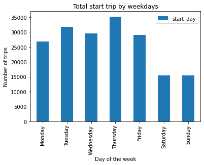

The day that has highest number of trips is Thursday, followed by Tuesday, Wednesday, Friday, and Monday. Saturday and Sunday are significantly lower than other weekdays.

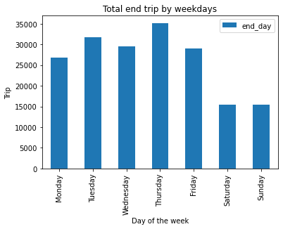

The day that has highest number of trips is Thursday, followed by Tuesday, Wednesday, Friday, and Monday. Saturday and Sunday are significantly lower than other weekdays.

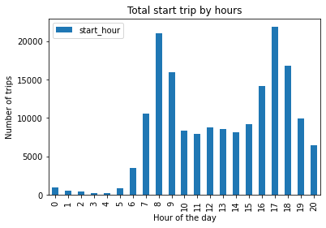

This chart has two peeaks, first one is at 8 o'clock and second one is at 17 o'clock.

The popular two hour windows are, 1) from 7 to 9 o'clock, and 2) from 16 to 18 o'clock

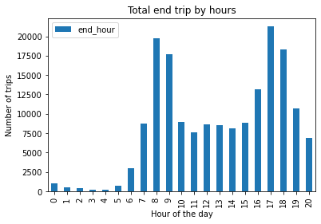

This chart has two peeaks, first one is at 8 o'clock and second one is at 17 o'clock.

The popular two hour windows are, 1) from 7 to 9 o'clock, and 2) from 16 to 18 o'clock

#### Demography

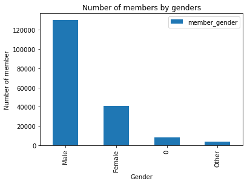

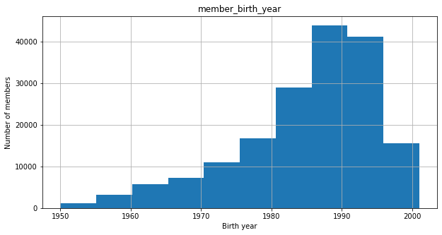

The chart is highly left skewed with most members are from 1975 to 2002.

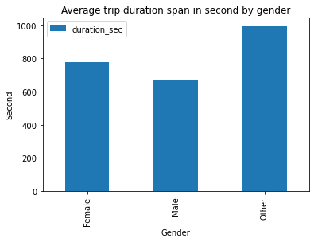

Bikers who identified their genders as 'Other' has the highest average duration span of 997 seconds or around 16.5 minutes.

Female bikers has the average trip span of 779 which is equivalent to 13 minutes.

Male bikers has the shortest trip span of 672 seconds or 11 minutes.

This could be Male bikers take shorter distance trips than Other and Female bikers, or it could be Male bikers have higher average speed. In order to investigate this indeth, we would need more data on trip distance and average speed.

| member_gender | duration_sec |
| --- | --- |
| Female | 779.070390 |
| Male | 672.639069 |
| Other | 996.515334 |

#### Location

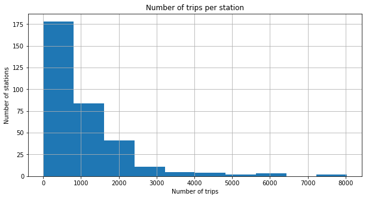

|  | start | end | total |
| --- | --- | --- | --- |
| count | 330.000000 | 330.000000 | 330.000000 |
| mean | 530.748485 | 530.748485 | 1061.496970 |
| std | 551.434598 | 598.350402 | 1145.063092 |
| min | 2.000000 | 5.000000 | 8.000000 |
| 25% | 155.000000 | 160.750000 | 315.750000 |
| 50% | 373.000000 | 356.500000 | 726.000000 |
| 75% | 730.250000 | 731.500000 | 1445.500000 |
| max | 3649.000000 | 4624.000000 | 8032.000000 |

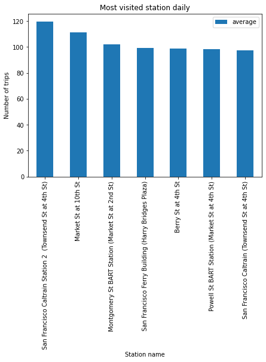

The 7 stations that have more than 90 visits on average per day are: 1) San Francisco Caltrain Station 2 (Townsend St at 4th St), 2) Market St at 10th St, 3) Montgomery St BART Station (Market St at 2nd St), 4) San Francisco Ferry Building (Harry Bridges Plaza), 5) Berry St at 4th St, 6) Powell St BART Station (Market St at 4th St), 7) San Francisco Caltrain (Townsend St at 4th St)

These are, no doubt, the most profitable stations.

|  | start | end | total | average |
| --- | --- | --- | --- | --- |
| San Francisco Caltrain Station 2 (Townsend St at 4th St) | 1571 | 1783 | 3354 | 119.785714 |
| Market St at 10th St | 1543 | 1569 | 3112 | 111.142857 |
| Montgomery St BART Station (Market St at 2nd St) | 1295 | 1561 | 2856 | 102.000000 |
| San Francisco Ferry Building (Harry Bridges Plaza) | 1298 | 1485 | 2783 | 99.392857 |
| Berry St at 4th St | 1410 | 1355 | 2765 | 98.750000 |
| Powell St BART Station (Market St at 4th St) | 1326 | 1428 | 2754 | 98.357143 |
| San Francisco Caltrain (Townsend St at 4th St) | 1322 | 1400 | 2722 | 97.214286 |

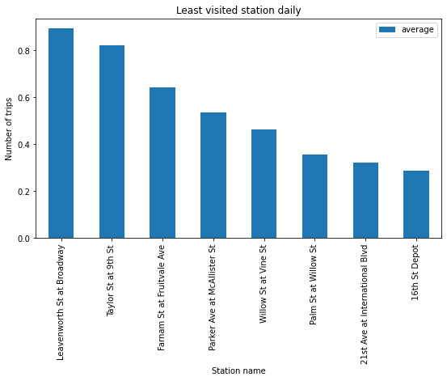

The 8 stations that have less than 1 visit per day are: 1) Leavenworth St at Broadway, 2) Taylor St at 9th St, 3) Farnam St at Fruitvale Ave, 4) Parker Ave at McAllister St, 5) Willow St at Vine St, 6) Palm St at Willow St, 7) 21st Ave at International Blvd, and 8) 16th St Depot.

These stations are potentially operating at a loss. Ford go bike should recosider whether to cotinue operate these stations.

|  | start | end | total | average |
| --- | --- | --- | --- | --- |
| Leavenworth St at Broadway | 13 | 12 | 25 | 0.892857 |
| Taylor St at 9th St | 13 | 10 | 23 | 0.821429 |
| Farnam St at Fruitvale Ave | 8 | 10 | 18 | 0.642857 |
| Parker Ave at McAllister St | 7 | 8 | 15 | 0.535714 |
| Willow St at Vine St | 8 | 5 | 13 | 0.464286 |
| Palm St at Willow St | 3 | 7 | 10 | 0.357143 |
| 21st Ave at International Blvd | 4 | 5 | 9 | 0.321429 |
| 16th St Depot | 2 | 6 | 8 | 0.285714 |

### Bivariate

In this section, I want to explore the relationship between start day and end day, start hour and end hour to see whether there's a significant difference in the number of trips.

The same thing goes with start and end station. I want to see whether people usually start at some stations but actually end at different stations.

For the demography, I want to see further breakdown of user types and bike shares by genders.

My theory is the same person would make two trips per day. One trip from their transit point to work - possibly in the morning and another trip from work back to the transit point - possibly in the evening.

#### Time

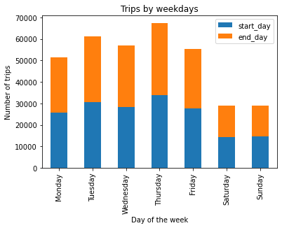

One of the reason this happens could be the majority of users only come to San Francisco during weekdays to work or use Ford bikes to commute to work. One thing Ford can do to boost the bikes usage during weekend is targeting tourists who usually spend weekends in San Francisco.

|  | start_day | end_day |
| --- | --- | --- |
| Monday | 25686 | 25686 |
| Tuesday | 30616 | 30623 |
| Wednesday | 28456 | 28447 |
| Thursday | 33733 | 33728 |
| Friday | 27682 | 27674 |
| Saturday | 14442 | 14450 |
| Sunday | 14532 | 14539 |

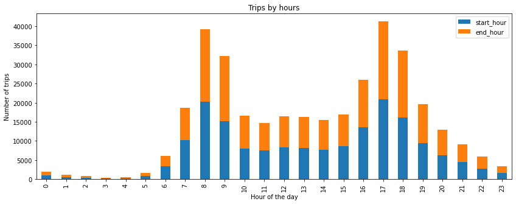

The most common start and end hours in the morning is from 8 to 9, and in the afternoon is from 17 to 18 also known as the rush hours. This again confirms the theory that most of the riders are professionals who use Ford bikes to commute to work.

|  | start_hour | end_hour |
| --- | --- | --- |
| 0 | 893 | 965 |
| 1 | 525 | 541 |
| 2 | 356 | 406 |
| 3 | 164 | 168 |
| 4 | 227 | 225 |
| 5 | 866 | 738 |
| 6 | 3294 | 2803 |
| 7 | 10235 | 8450 |
| 8 | 20242 | 19027 |
| 9 | 15221 | 16988 |
| 10 | 7980 | 8551 |
| 11 | 7473 | 7221 |
| 12 | 8237 | 8158 |
| 13 | 8118 | 8101 |
| 14 | 7694 | 7716 |
| 15 | 8657 | 8302 |
| 16 | 13492 | 12546 |
| 17 | 20921 | 20339 |
| 18 | 16133 | 17487 |
| 19 | 9432 | 10234 |
| 20 | 6220 | 6630 |
| 21 | 4401 | 4703 |
| 22 | 2793 | 3100 |
| 23 | 1573 | 1748 |

#### Demography

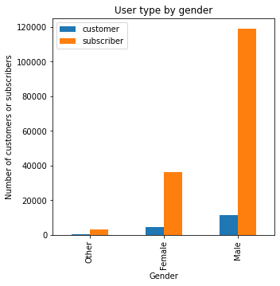

However, the number of Male customers is 2.5 times higher than Female customers and is 25 times higher than Other customers; And the number of Male subscribers is 3 times higher than Female subscribers, and is 38 times higher than Other subscribers, despite Other and Female have higher trip duration on average.

Ford Go Bike service clearly attracts more Male users than Female and Other users. Ford Go Bike team should do in-depth persona research and user interviews to find out why their product and service do not attract Female and Other users that well.

|  | customer | subscriber |
| --- | --- | --- |
| Other | 455 | 3197 |
| Female | 4647 | 36197 |
| Male | 11529 | 119122 |

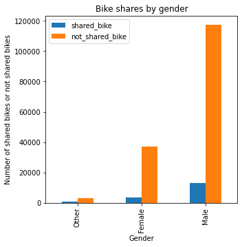

This ratio in shared bike users is 1:6:20

|  | shared_bike | not_shared_bike |
| --- | --- | --- |
| Other | 648 | 3004 |
| Female | 3600 | 37244 |
| Male | 13111 | 117540 |

#### Location

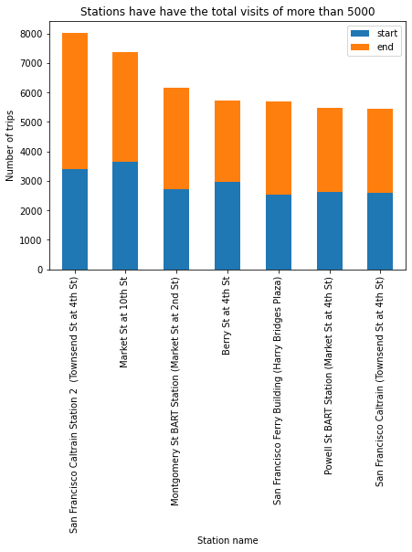

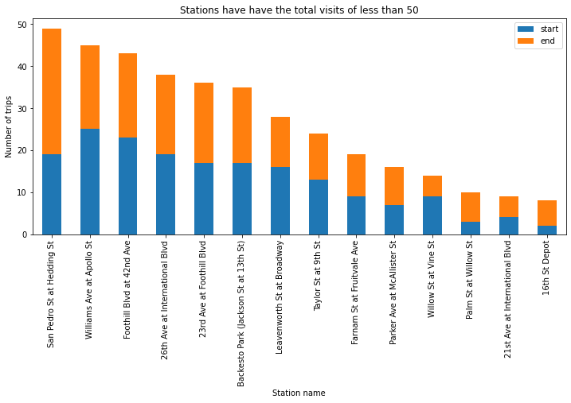

### Multivariates

In this section, I want to explore the dataset with more angles and dimensions. I categorize data into smaller group with three varibles or conditions.

What I'm ineterested in:

1) The most popular date and time when people start their trip.

2) The most popular date and time when people end their trip.

3) The most to least popular customer group by age, gender, user type, bike sharing status.

4) The most popular routes.

My findings were:

1) Most trips start between 7 AM - 9 AM and 4 PM - 6 PM from Monday to Friday.

2) Most trips also ends between 7 AM - 9 AM and 4 PM - 6 PM from Monday to Friday.

3) The top 3 popular groups are Gen Y subscriber, Gen Y not sharing bike, and Gen Y Males.

4) The most popular route is from station 81 - Berry St at 4th St- to station 15 - San Francisco Ferry Building- in Feb 2019 with 337 trips.

#### Time

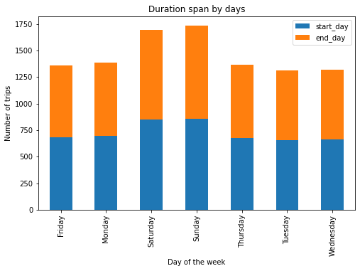

Saturday and Sunday have the highest trip duration compare to other week days. People may have more spare time during weekend to take longer trips.

| start_day | start_day | end_day |
| --- | --- | --- |
| Friday | 681.507189 | 676.563634 |
| Monday | 697.104064 | 691.823678 |
| Saturday | 850.583299 | 841.912872 |
| Sunday | 859.202243 | 875.019809 |
| Thursday | 678.421338 | 687.227526 |
| Tuesday | 652.897015 | 658.240734 |
| Wednesday | 665.060514 | 654.674201 |

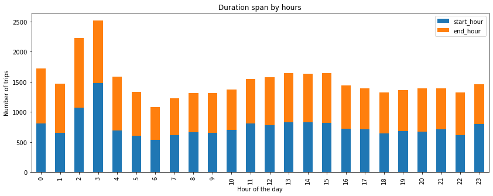

| start_hour | start_hour | end_hour |
| --- | --- | --- |
| 0 | 808.895857 | 912.940933 |
| 1 | 652.451429 | 818.715342 |
| 2 | 1067.620787 | 1158.184729 |
| 3 | 1471.884146 | 1041.815476 |
| 4 | 685.189427 | 896.564444 |
| 5 | 601.254042 | 732.925474 |
| 6 | 534.712508 | 544.757046 |
| 7 | 613.838202 | 609.997278 |
| 8 | 656.268551 | 654.341567 |
| 9 | 651.777084 | 658.414351 |
| 10 | 698.862531 | 674.561572 |
| 11 | 803.581560 | 743.295942 |
| 12 | 777.225203 | 796.308532 |
| 13 | 829.518231 | 808.048142 |
| 14 | 828.410190 | 807.933515 |
| 15 | 813.089638 | 831.675018 |
| 16 | 722.316113 | 717.128487 |
| 17 | 704.853305 | 687.879247 |
| 18 | 641.890411 | 676.839709 |
| 19 | 684.927163 | 676.824897 |
| 20 | 674.456913 | 710.180543 |
| 21 | 712.743922 | 677.063576 |
| 22 | 612.354816 | 706.946129 |
| 23 | 793.734266 | 664.211670 |

Most trip starts at 08 in the morning and again at 17 in the afternoon, following by trips start at 09 and 18. Tuesday and Thursday have the highest number of trips. Saturday and Sunday have the lowest number of trips.

The number of trips from after 11PM to before 6AM is insignificant.

Most trip ends at 08 in the morning and again at 17 in the afternoon, following by trips start at 09 and 18. Tuesday and Thursday have the highest number of trips. Saturday and Sunday have the lowest number of trips.

The number of trips from after 11PM to before 6AM is insignificant.

#### Demography

Number of total subscribers are 158,162 which is 9.5 times higher than customers at 16,615. This is a good sign because subscriber has higher life time value for the service than the customer as the subscriber usually use this service on a day basis. Similar to that, most of the bikes are not shared which means higher value for Ford.

Come second across all categories are Gen X users with 27,250 male users, 6,843 female users, 869 other users, a total account of 31,930 subscribers, 3,132 cutomers, 31,832 not shred bike and 3230.

The third most popular group is Gen Z. One theory why Gen Z is not the popular users yet is that not many Gen Z are professionals who work in downtown San Francisco. However, Gen Z users may be blooming in couple years. One way to examinize this is to look at the growth of Gen Z users over the year.

#### Location

The most popular route is from station 81 - Berry St at 4th St- to station 15 - San Francisco Ferry Building- in Feb 2019 with 337 trips.

The second popular route starts at station 58 - Market St at 10th St - and ends at station 21 - Montgomery St BART Station.

The third popular route is also starts at station 58, but ends at station 3 which is Powell St BART Station.

The fourth popular route again starts at station 58, but ends at station 67 which is San Francisco Caltrain Station 2